# STAT400 Final Project, JHU COVID-19 Reported Cases and Deaths in Maryland, May 2021

May Kyaw, Maria Malishev, Thanushree Manjunath, Kenth Santibanez Rivera, and Chinmay Sevak

# 1 Introduction

This report evaluates the change in average daily infections and deaths due to the COVID-19 virus in Maryland before and after major COVID-19 vaccinations efforts were undertaken in the state, and draws conclusion about the efficacy of vaccinations int he population of Maryland. The world has reached globalization levels which make any single country’s problem, the entire world’s problem with an ever connected world economy, politics, and people demographics. Thus, understanding what happens in the state of Maryland during this COVID-19 world pandemic, and how effective vaccines are are mitigating infections and deaths in it’s population due to COVID-19 offer valuable insights into the importance of safeguarding and preparing against future pandemics in Maryland and the world.

# 2 Analysis/Visualizations

```r
# Filter data for new infection cases by pre and post vaccine efforts
cases_prevaccine <- (Maryland_cases[(start_ind):(vacc_ind-1)])-(Maryland_cases[(start_ind-1):(vacc_ind-2)]) # indices offset subtraction to get daily cases
mu1 <- mean(cases_prevaccine) # compute daily mean

cases_postvaccine <- (Maryland_cases[(vacc_ind+1):end_ind])-(Maryland_cases[vacc_ind:(end_ind-1)])
mu2 <- mean(cases_postvaccine) # compute daily mean

# Filter data for deaths by pre and post vaccine efforts
deaths_prevaccine <- (Maryland_deaths[(start_ind):(vacc_ind-1)])-(Maryland_deaths[(start_ind-1):(vacc_ind-2)])# indices offset subtraction to get daily deaths
mu3 <- mean(deaths_prevaccine) # compute daily mean

deaths_postvaccine <- (Maryland_deaths[(vacc_ind+1):end_ind])-(Maryland_deaths[vacc_ind:(end_ind-1)])
mu4 <- mean(deaths_postvaccine) # compute daily mean

# Tabulate the means from above and display
tab <- as.table(rbind(c(mu1,mu3), c(mu2,mu4)))
dimnames(tab) <- list(Time_of_Metric = c("Pre Vaccine", "Post vaccine"),
Metric_Daily_Mean = c("Reported New Cases", "Reported Deaths"))
tab
```

```
##               Metric_Daily_Mean
## Time_of_Metric Reported New Cases Reported Deaths
##   Pre Vaccine          2424.58000        34.02000
##   Post vaccine         1335.22764        22.81301
```

## 2.1 Create Plots

Two plots created. One for new reported cases and one for deaths related to the virus. Vertical lines were drawn in reference to the date when different phases of the vaccination efforts were undertaken in Maryland. Phase 1a vaccine available for all first line responders (nurses, police, EMT, Heath Care Workers) Phase 2a vaccine available for people 60 years or older Phase 3 vaccine available for people 16 years or older In particular, a black dashed vertical line was placed to reference where the the data to be analyzed beginnings The team decided to begin the date from there to prevent large skewness in the analysis

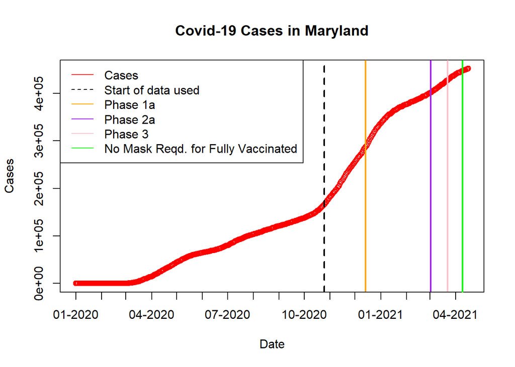

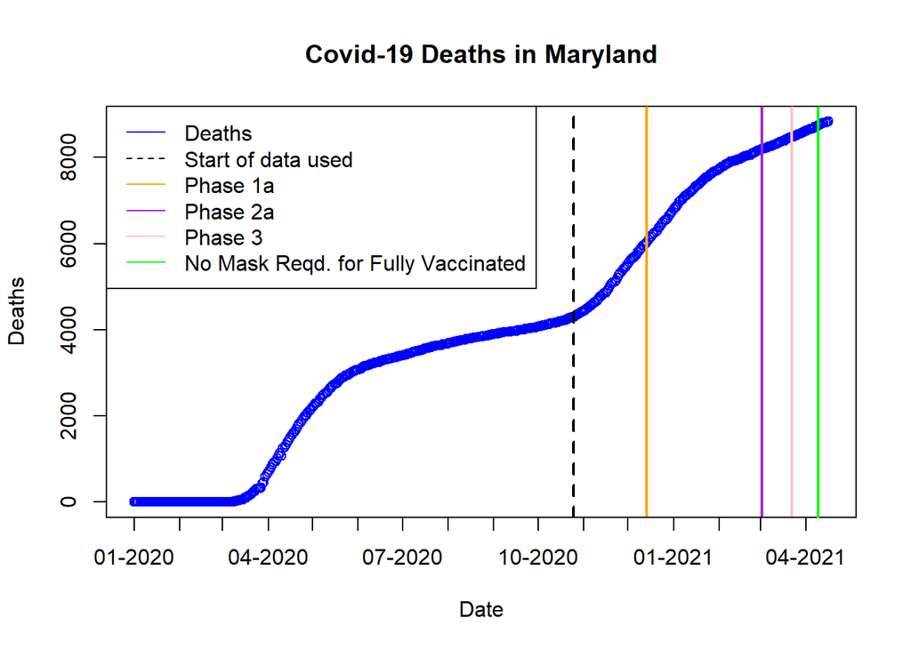